# NaturalLanguageProcessingBasics

Importing required packages

```python
from __future__ import unicode_literals

%matplotlib inline
import matplotlib.pyplot as plt
plt.style.use('bmh')

import warnings
warnings.filterwarnings('ignore')

import pandas as pd
from collections import Counter
from textblob import TextBlob
import re
import nltk
import xgboost as xgb
import numpy as np
import collections
import operator
import itertools
import os


from nltk.corpus import stopwords
import nltk.stem.snowball
st = nltk.stem.snowball.SnowballStemmer('english')
from nltk.stem import WordNetLemmatizer, SnowballStemmer
stemmer = SnowballStemmer('english')

from sklearn.model_selection import train_test_split, ShuffleSplit, learning_curve
from sklearn.linear_model import LogisticRegression
from sklearn.ensemble import RandomForestClassifier
from sklearn.naive_bayes import MultinomialNB
from sklearn.pipeline import Pipeline
from sklearn.feature_extraction.text import CountVectorizer, TfidfVectorizer, TfidfTransformer
from sklearn.metrics import classification_report, accuracy_score ,confusion_matrix
from sklearn.linear_model import SGDClassifier
from sklearn import preprocessing
from sklearn.preprocessing import LabelBinarizer, LabelEncoder
from sklearn.svm import SVC
from sklearn import utils

from yellowbrick.text import FreqDistVisualizer

import gensim
from gensim.models import Word2Vec
from gensim.models import Doc2Vec
from gensim.models import Phrases
from gensim.models.phrases import Phraser
from gensim import models
from gensim.models.doc2vec import TaggedDocument
import pyLDAvis.gensim as gensimvis

from itertools import islice

import tensorflow as tf
from tensorflow import keras
from keras.models import Sequential
from keras.layers import Dense, Activation, Dropout
from keras.preprocessing.text import Tokenizer
from keras.preprocessing import text, sequence
from keras.preprocessing.sequence import pad_sequences
from keras.layers import Dense, Embedding, LSTM, SpatialDropout1D
from keras.callbacks import EarlyStopping
from keras import utils

from tqdm import tqdm
tqdm.pandas(desc="progress-bar")

import spacy
from spacy_langdetect import LanguageDetector
nlp = spacy.load('en')

from wordcloud import WordCloud

import plotly
plotly.tools.set_credentials_file(username='avinashok', api_key='SZBL9GagG9yPYCwfSuDc')
import plotly.plotly as py
import plotly.graph_objs as go
```

### Exploratory Data Analysis

Variable Standardization

```python
#Directories
dataDirectory = "../Data/"
```

Reading Data file

```python
# reading data file
df = pd.read_csv(dataDirectory+'CustomerInteractionData.csv')

#Randomly shuffling data
df = df.sample(len(df))

#Copying the Raw comment column for Future Use
df['CustomerInteractionText'] = df['CustomerInteractionRawText']

#Checking the initial 5 rows
df.head(5)
```

|  | RecordID | CustomerInteractionRawText | AgentAssignedTopic | LocationID | CallDurationSeconds | AgentID | CustomerID | CustomerInteractionText |
| --- | --- | --- | --- | --- | --- | --- | --- | --- |
| 61 | 1890102 | Cus called in to change plan. | Change Plans | 4.0 | 18.0 | b1hpA | 9QL2A | Cus called in to change plan. |
| 89 | 1890130 | Data usage not matching with actual. Provided ... | Data Usage | 0.0 | 15.0 | 0Fbql | X5Xnj | Data usage not matching with actual. Provided ... |
| 11 | 1890052 | Low speed connection reported in Uppala area. | Poor Connectivity | 3.0 | 17.0 | eUYn2 | movRl | Low speed connection reported in Uppala area. |
| 25 | 1890066 | Cus want to enquire about the high bill for re... | High Bill | 1.0 | 10.0 | DcSrK | pAESa | Cus want to enquire about the high bill for re... |
| 92 | 1890133 | Reported sad demise of customer. | Others | 2.0 | 19.0 | o6cXs | jD51a | Reported sad demise of customer. |

```python
#Objects Used
commentTextColumn = 'CustomerInteractionText'
agentAssignedColumn = 'AgentAssignedTopic'
locationID = 'LocationID'
callDuration = 'CallDurationSeconds' #In Seconds
agentID = 'AgentID'
customerID = 'CustomerID'
rawText = 'CustomerInteractionRawText'
```

### Checking Data Quality

By doing a Data Quality Check we are:

- Identifying a unique column which can be assigned as a Primary Key column (incase it wasn't specified initially.)
- Making sure all the columns are having the required datatypes
- Calculating the Null Values, Duplicate values, etc. (Maximum, Minimum, Range in case its a numeric column.).
- Creating visualizations to understand the Data Quality level of input data.

```python
# Identifying Primary Key

print("Number of Columns in the Dataset = " + str(len(df.columns)))

uniqueColumns=[]
for col in df.columns.to_list():
    if len(df[str(col)].unique())==df.shape[0]:
        uniqueColumns.append(col)
if len(uniqueColumns)==1:
    primaryKeyColumn = str(uniqueColumns[0])
    print("Primary Key = "+primaryKeyColumn)
```

[output not shown]

```python
# Checking Datatypes of each columns in the dataset
print(df.dtypes)

# Specifying datatypes we want for each column
dataTypeDictionary = {
    primaryKeyColumn: 'int64',
    commentTextColumn: 'object',
    rawText:'object',
    agentAssignedColumn: 'object',
    locationID: 'int64',
    callDuration: 'int64',
    agentID: 'object',
    customerID: 'object'

 }
```

```
RecordID                        int64
CustomerInteractionRawText     object
AgentAssignedTopic             object
LocationID                    float64
CallDurationSeconds           float64
AgentID                        object
CustomerID                     object
CustomerInteractionText        object
dtype: object
```

```python
duplicatesCount = {}
for col in df.columns.to_list():
    duplicatesCount[col] = [((df.duplicated(col).sum()/len(df))*100),100-((df.duplicated(col).sum()/len(df))*100)]

nullCounter = {}
for col in df.columns.to_list():
    count = 0
    for cell in df[str(col)]:
        if cell=='?' or cell=="":   # or len(str(cell))==1
            count= count +1
    nullCounter[col]=[float(count/len(df))*100,100-float(count/len(df))*100]
```

```python
def dataQualityCheck(checkName, columnName):
    if checkName == "Null Values":
        # create data
        names='Null Values', 'Non Null Values',
        size=np.array(nullCounter[columnName])
        print("Null Values Data Quality Check for "+str(columnName))
        def absolute_value(val):
            a  = np.round(val/100.*size.sum(), 0)
            return a
        # Create a circle for the center of the plot
        my_circle=plt.Circle( (0,0), 0.7, color='white')

        # Custom colors --> colors will cycle
        plt.pie(size, labels=names, colors=['red','green'],autopct=absolute_value)
        p=plt.gcf()
        p.gca().add_artist(my_circle)
        plt.show();
    elif checkName =="Duplicates":
                # create data
        names='Duplicate Values', 'Unique Values Values',
        size=np.array(duplicatesCount[columnName])
        print("Duplicate Value Data Quality check for "+str(columnName))
        def absolute_value(val):
            a  = np.round(val/100.*size.sum(), 0)
            return a
        # Create a circle for the center of the plot
        my_circle=plt.Circle( (0,0), 0.7, color='white')

        # Custom colors --> colors will cycle
        plt.pie(size, labels=names, colors=['red','green'],autopct=absolute_value)
        p=plt.gcf()
        p.gca().add_artist(my_circle)
        plt.show();
    elif checkName == "Details":
        print("Details of the Column: \n ")
        print("Original Datatype should be "+dataTypeDictionary[columnName]+"\n")
        print("Datatype in the data is "+str(df[str(columnName)].dtypes)+"\n")
    elif checkName == "Range":
        if str(df[str(columnName)].dtypes)=='int64' or str(df[str(columnName)].dtypes)=='datetime64[ns]':
            print("Maximum Value is "+str(df[str(columnName)].max())+" \n ")
            print("Minimum Value is "+str(df[str(columnName)].min()))
        else:
            print("Since the Datatype of column "+str(columnName)+" is not numeric in the given data, Range cannot be calculated.")


def dQexecute(columnName):
    print("\n Name of the Column "+str(columnName)+"\n \n")
    dataQualityCheck("Details",columnName)
    dataQualityCheck("Null Values",columnName)
    dataQualityCheck("Duplicates",columnName)
    dataQualityCheck("Range",columnName)
    print("*****************")
```

```
 Name of the Column RecordID


Details of the Column:

Original Datatype should be int64

Datatype in the data is int64

Null Values Data Quality Check for RecordID
```

```
Duplicate Value Data Quality check for RecordID
```

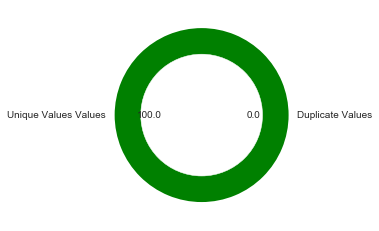

```
Maximum Value is 1890143

Minimum Value is 1890041
*****************

 Name of the Column CustomerInteractionRawText


Details of the Column:

Original Datatype should be object

Datatype in the data is object

Null Values Data Quality Check for CustomerInteractionRawText
```

```
Duplicate Value Data Quality check for CustomerInteractionRawText
```

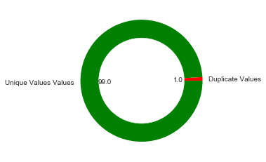

```
Since the Datatype of column CustomerInteractionRawText is not numeric in the given data, Range cannot be calculated.
*****************

 Name of the Column AgentAssignedTopic


Details of the Column:

Original Datatype should be object

Datatype in the data is object

Null Values Data Quality Check for AgentAssignedTopic
```

```
Duplicate Value Data Quality check for AgentAssignedTopic
```

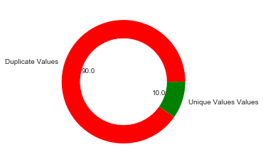

```
Since the Datatype of column AgentAssignedTopic is not numeric in the given data, Range cannot be calculated.
*****************

 Name of the Column LocationID


Details of the Column:

Original Datatype should be int64

Datatype in the data is float64

Null Values Data Quality Check for LocationID
```

```
Duplicate Value Data Quality check for LocationID
```

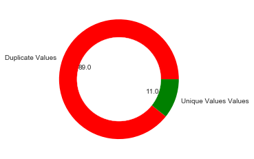

```
Since the Datatype of column LocationID is not numeric in the given data, Range cannot be calculated.
*****************

 Name of the Column CallDurationSeconds


Details of the Column:

Original Datatype should be int64

Datatype in the data is float64

Null Values Data Quality Check for CallDurationSeconds
```

```
Duplicate Value Data Quality check for CallDurationSeconds
```

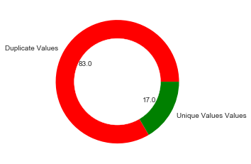

```
Since the Datatype of column CallDurationSeconds is not numeric in the given data, Range cannot be calculated.
*****************

 Name of the Column AgentID


Details of the Column:

Original Datatype should be object

Datatype in the data is object

Null Values Data Quality Check for AgentID
```

```
Duplicate Value Data Quality check for AgentID
```

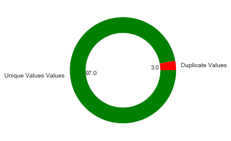

```
Since the Datatype of column AgentID is not numeric in the given data, Range cannot be calculated.
*****************

 Name of the Column CustomerID


Details of the Column:

Original Datatype should be object

Datatype in the data is object

Null Values Data Quality Check for CustomerID
```

```
Duplicate Value Data Quality check for CustomerID
```

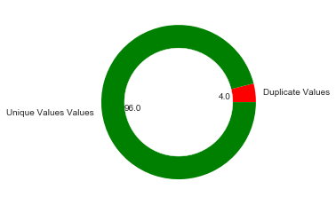

```
Since the Datatype of column CustomerID is not numeric in the given data, Range cannot be calculated.
*****************

 Name of the Column CustomerInteractionText


Details of the Column:

Original Datatype should be object

Datatype in the data is object

Null Values Data Quality Check for CustomerInteractionText
```

```
Duplicate Value Data Quality check for CustomerInteractionText
```

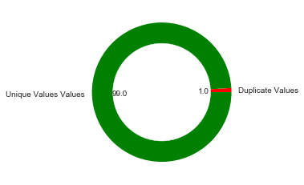

```
Since the Datatype of column CustomerInteractionText is not numeric in the given data, Range cannot be calculated.
*****************
```

```python
for col in df.columns.to_list():
    dQexecute(col)
```

### Agent Assigned Topic Distribution Analysis

For visualizing Topic distribution, we use the package [plotly](https://plot.ly/) which makes the bar charts more interactive.

```python
z = {}
uniqueTopics = list(df[agentAssignedColumn].unique())
for i in uniqueTopics:
    z[i]=i

data = [go.Bar(x = df[agentAssignedColumn].map(z).unique(),y = df[agentAssignedColumn].value_counts().values,
        marker= dict(colorscale='Jet',color = df[agentAssignedColumn].value_counts().values),text='Number of Calls for this reason')]

layout = go.Layout(title='Reasonwise Call Distribution')

fig = go.Figure(data=data, layout=layout)

py.iplot(fig, filename='TelecomCallDistribution')
```

[interactive chart not shown]

### Analyzing the Word Count for each Reasons

- We can check average Word count for each reasons. At times taking Median word count might also be useful.

```python
df['totalwords'] = df[commentTextColumn].str.split().str.len()
def reasonCodeLevelWordCount(reasonCode, parameter):
    dfReasonCodeSubset = df[df[agentAssignedColumn]==reasonCode]
    if parameter == 'mean':
        return float(dfReasonCodeSubset.describe()['totalwords'][1])
    elif parameter == 'median':
        return float(dfReasonCodeSubsett.describe()['totalwords'][5])
```

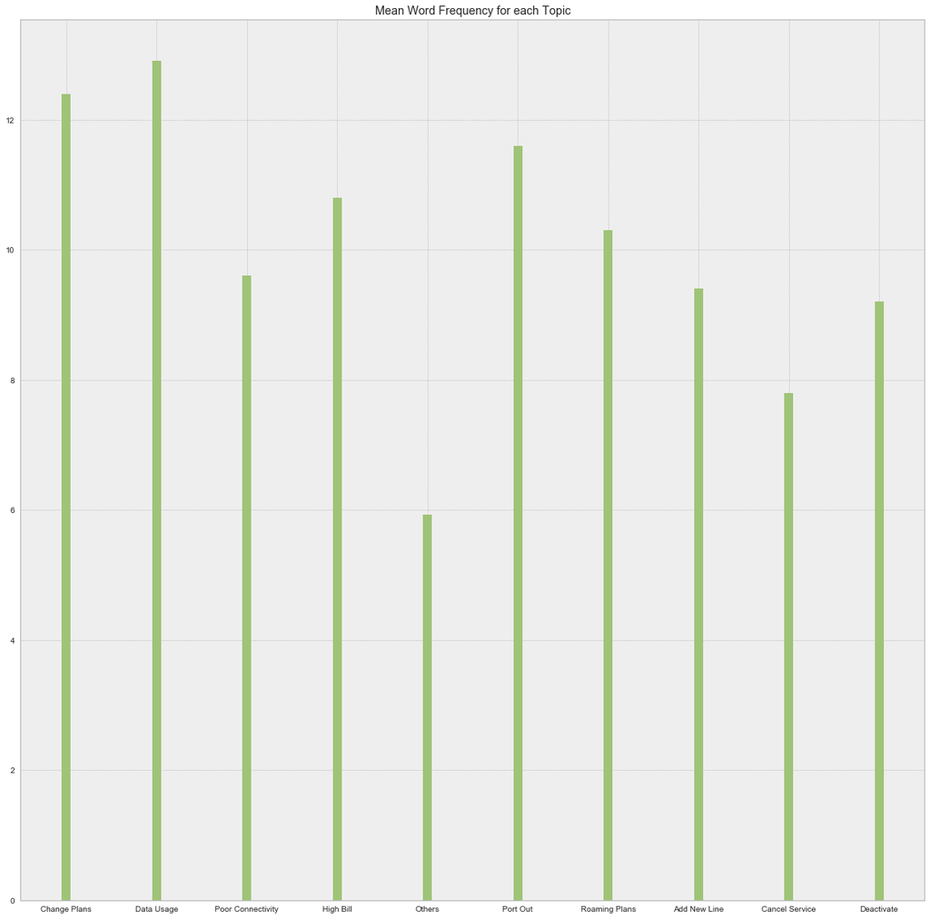

```python
# Mean Word Count
reasonCodeDict = {}
for topic in uniqueTopics:
    reasonCodeDict[str(topic)]=float(reasonCodeLevelWordCount(topic, 'mean'))
plt.figure(figsize=(20,20))
plt.title("Mean Word Frequency for each Topic", fontdict=None, loc='center')
plt.bar(reasonCodeDict.keys(), reasonCodeDict.values(), width = 0.1  , color='g')
plt.show()

print("\n\n ******************** \n\n ")

# #Median Word Count (Optional)
# reasonCodeDict = {}
# for topic in uniqueTopics:
#     reasonCodeDict[str(topic)]=float(reasonCodeLevelWordCount(topic, 'median'))
# plt.figure(figsize=(20,20))
# plt.title("Median Word Frequency for each Topic", fontdict=None, loc='center')
# plt.bar(reasonCodeDict.keys(), reasonCodeDict.values(), width = 0.1  , color='g')
# plt.show()
```

### Visualize Token (vocabulary) Frequency Distribution Before Text Preprocessing

Visualizing frequency distribution of top words helps us in two ways:

- Determine which words needs to be removed & devising a process flow of cleaning the text.
- Comparing the Frequency distribution "Before" & "After" Text Preprocessing gives us a visual idea about how well we are cleaning the data for modelling.

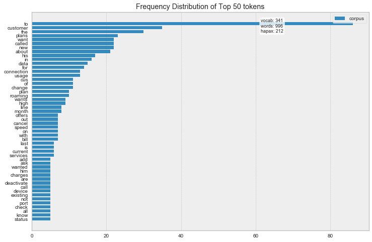

```python
vectorizer = CountVectorizer()
docs       = vectorizer.fit_transform(df[commentTextColumn])
features   = vectorizer.get_feature_names()
plt.figure(figsize=(12,8))
visualizer = FreqDistVisualizer(features=features)
visualizer.fit(docs)
for label in visualizer.ax.texts:
    label.set_size(20)
visualizer.poof()
```

## Text Preprocessing

In Text Preprocessing, we are performing multiple Natural Language Processing techniques. The idea is to get noise-free standardized text which can be taken for used readily for Modelling. Steps of Preprocessing largely depends on the dataset we are dealing with. In this case the Text Preprocessing comprises of the following steps:

- Object Standardization: Since the free text we have were written by Call Centre agents, they use a lot of domain specific Short Hands, abbreviations, etc. which are not present in any standard lexical dictionaries. But then, at certain times, they write the full form or complete word. Object Standardization strike a balance between these & use a same form of word through out the dataset.
- Named Entity Recognition(NER): Detecting names of 'Person', 'Location', 'Product' etc. and removing them from the dataset as they don't specifically add much value to our final model. (Note: There are cases where such entities are important & should be retained in some format.). We use [SpaCy](https://spacy.io/usage/linguistic-features) for NER.
- Other Language Identification: Since the data we have comes from different locations, there could be a possibility of other languages present in the data. We use `spacy_langdetect` for identifying them and removing them.
- Alphanumeric removal: Since this is Telecom Call centre data, there are a lot of alphanumeric words involved. For eg: 3G, 20MBps, agentID: '4ap2X', etc. We can keep it or remove it as per requirement.
- Text Cleaning: Next we remove all the special characters, ASCII characters, numbers, single character words, etc.
- Autocorrection: The agent comments might have a lot of spelling mistakes, typos etc. We try to correct atleast some of them using `TextBlob` Autocorrection.
- Lexicon Normalization: We also normalize multiple representations of a word to its etymological root form. For eg: 'wanted', 'wanting', 'want' becomes > 'want'

After this we perform the following operations on the dataset:

- Remove null comments.
- Remove duplicate comments (keeping its first occurance.)
- Remove comments with just one word.

### Object Standardization

```python
%%time

abbrevationDictionary = {'Cus': 'customer', 'cus': 'customer',
                        'Xferred':'transferred', 'xferred': 'transferred'}

#Function to Standardize Text
def objectStandardization(input_text):
    words = str(input_text).split()
    new_words = []
    for word in words:
        word = re.sub('[^A-Za-z0-9\s]+', ' ', word) #remove special characters
        if word.lower() in abbrevationDictionary:
            word = abbrevationDictionary [word.lower()]
        new_words.append(word)
    new_text = " ".join(new_words)
    return new_text

df[commentTextColumn] = df[commentTextColumn].apply(objectStandardization)

print(df[commentTextColumn].head(5))
```

```
61                   customer called in to change plan
89    Data usage not matching with actual  Provided ...
11        Low speed connection reported in Uppala area
25    customer want to enquire about the high bill f...
92                     Reported sad demise of customer
Name: CustomerInteractionText, dtype: object
Wall time: 8.98 ms
```

Named Entity Recognition

```python
%%time

# Function to extract Names of persons, organizations, locations, products etc. from the dataset
def entityCollector(df):
    listOfNames = []
    for index, row in df.iterrows():
        doc = nlp(row[str(commentTextColumn)])
        fil = [(i.label_.lower(), i) for i in doc.ents if i.label_.lower() in ["person", "gpe", "product"]] # Extracts Person Names, Organization Names, Location, Product names
        if fil:
            listOfNames.append(fil)
        else:
            continue
    flat_list = [item for sublist in listOfNames for item in sublist]
    entityDict = {}
    for a, b in list(set(flat_list)):
        entityDict.setdefault(a, []).append(b)
    return entityDict

entityDict = entityCollector(df)

print("\n Types of entities present in the data are: "+", ".join(list(entityDict.keys()))+" \n")
```

```
 Types of entities present in the data are: person, gpe

Wall time: 1.67 s
```

Creating a custom Stop Word List

```python
%%time
for entity in list(entityDict.keys()):
    entityDict[entity] = [str(i) for i in entityDict[entity]]

ignoreWords = []
for key in entityDict.keys():
    ignoreWords.append(entityDict[key])
ignoreWords = [item for sublist in ignoreWords for item in sublist]

print("Number of words in Custom Stopword list = "+str(len(ignoreWords)))
```

```
Number of words in Custom Stopword list = 18
Wall time: 18 ms
```

Identify the Language Distribution

```
Some sample other language texts:

[1890085, 'Add a new line.', 'Add New Line', 8.0, 5.0, '8ysiF', 'wXMyg', 'Add a new line ', 4, 'cy']
[1890131, 'Customer demise.', 'Others', 7.0, 8.0, '5HHnN', 'svkC5', 'Customer demise ', 2, 'de']
[1890102, 'Cus called in to change plan.', 'Change Plans', 4.0, 18.0, 'b1hpA', '9QL2A', 'customer called in to change plan ', 6, 'en']
[1890143, 'Se verificaron nuevas aplicaciones en el mercado.', 'Others', 7.0, 10.0, '4ntG8', '9a6f9', 'Se verificaron nuevas aplicaciones en el mercado ', 7, 'es']
[1890142, '#call?', 'Others', nan, nan, nan, nan, ' call ', 1, 'it']
Wall time: 6.63 s
```

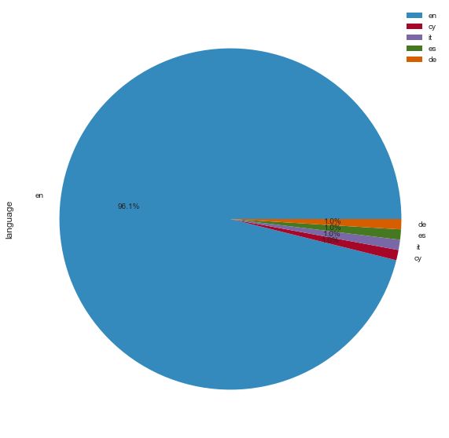

```python
%%time
def languageDistribution(df):
    nlp = spacy.load("en")
    nlp.add_pipe(LanguageDetector(), name="language_detector", last=True)
    df['language']=''
    language = []
    for index, row in df.iterrows():
        text = row[str(commentTextColumn)]
        doc = nlp(text)
        language.append(str(doc._.language['language']))
    df['language'] = language
    return df

df = languageDistribution(df)
langDict = df.groupby('language')[str(primaryKeyColumn)].nunique().to_dict()

otherLanguagesList = list(langDict.keys()).remove('en')
print("Some sample other language texts: \n")
for lang in list(langDict.keys()):
    print(str(df[df['language']==str(lang)].values.tolist()[0]))

##Plot a Pie Distribution of Language Distribution
bin_percent = pd.DataFrame(df['language'].value_counts(normalize=True) * 100)
plot = bin_percent.plot.pie(y='language', figsize=(10, 10), autopct='%1.1f%%')

#Dropping only the row with Spanish text
df = df.drop(df[df['language'] == 'es'].index);
```

Identify Words which contains numbers in it

```
How many top words do you want? maximum= 3
 3
{'3g': 3, '1mbps': 2, '935468r911': 1}
```

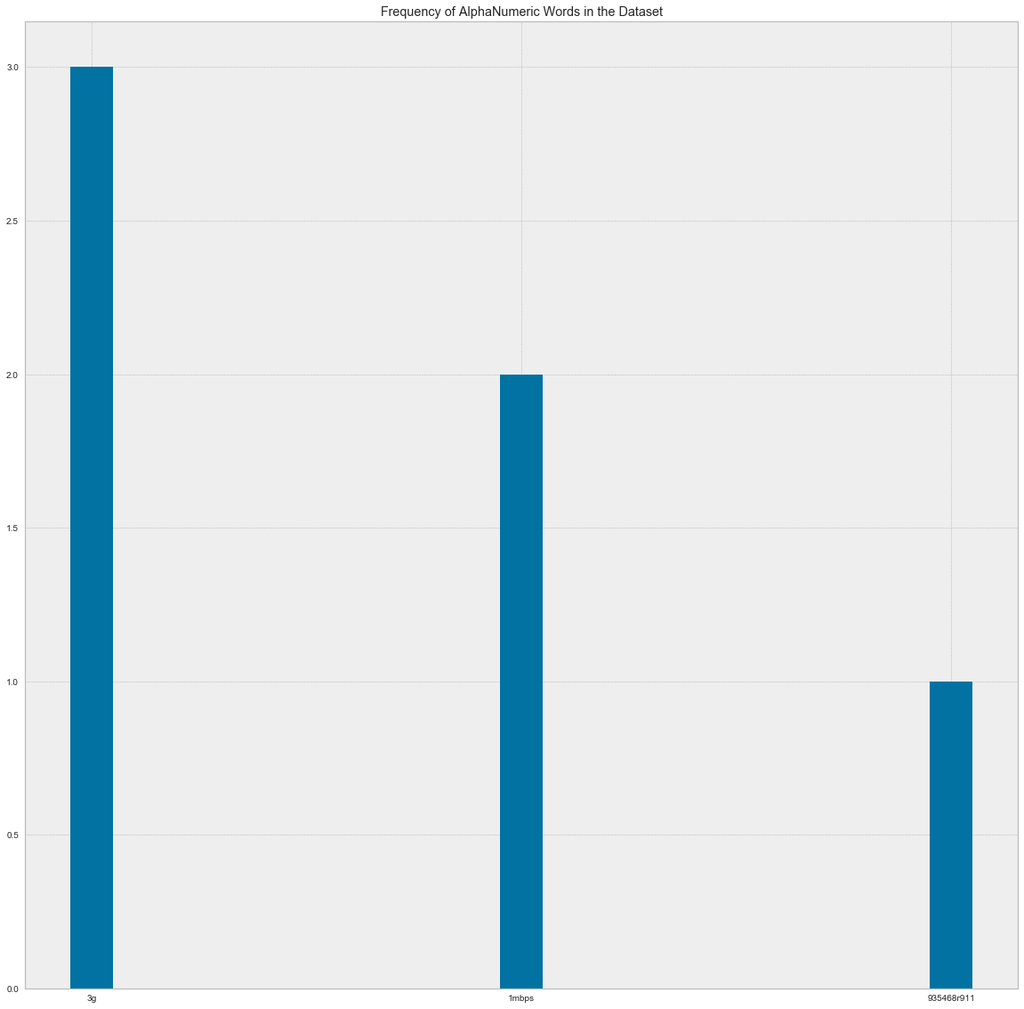

```
Wall time: 4.65 s
```

```python
%%time
#Function to extract Alpha numeric words
def alphanumericExtractor(input_text):
    words = str(input_text).split()
    alphanumericWordlist = []
    for word in words:
        word = re.sub('[^A-Za-z0-9\s]+', '', word.lower()) #remove special characters
        word = re.sub(r'[^\x00-\x7F]+',' ', word) # remove ascii
        if not word.isdigit() and any(ch.isdigit() for ch in word):
            alphanumericWordlist.append(word)
        else:
            continue
    return alphanumericWordlist

#Function to get the frequency of Alphanumeric words in the data
def alphanumericFrequency(df, commentTextColumnName):
    alphanumericWordsList = []
    for index, row in df.iterrows():
        if alphanumericExtractor(row[str(commentTextColumnName)]):
            alphanumericWordsList.append(alphanumericExtractor(row[str(commentTextColumnName)]))
        else:
            continue
    flat_list = [item for sublist in alphanumericWordsList for item in sublist]
    counts = Counter(flat_list)
    countsdict = dict(counts)
    return countsdict

# Final list of alphanumeric words
alphanumericWordFreqDict = alphanumericFrequency(df, commentTextColumn)

# To plot the distribution
totalWordcount = len(alphanumericWordFreqDict)

topWordCount = input('How many top words do you want? maximum= '+str(totalWordcount)+ ' \n ')
# topWordCount = totalWordcount

alphanumericWordFreqDictTop = dict(sorted(alphanumericWordFreqDict.items(), key=operator.itemgetter(1), reverse=True)[:int(topWordCount)])
print(alphanumericWordFreqDictTop)

plt.figure(figsize=(20,20))
plt.title('Frequency of AlphaNumeric Words in the Dataset', fontdict=None, loc='center')
plt.bar(alphanumericWordFreqDictTop.keys(), alphanumericWordFreqDictTop.values(), width = 0.1  , color='b');
plt.show();

#Updating Custom stopword list with Alphanumeric words
ignoreWords = ignoreWords + list(alphanumericWordFreqDict.keys())
```

Text Cleaning

```python
def clean_text(newDesc):
    newDesc = re.sub('[^A-Za-z\s]+', '', newDesc) #remove special characters
    newDesc = re.sub(r'[^\x00-\x7F]+','', newDesc) # remove ascii
    newDesc = ' '.join( [w for w in newDesc.split() if len(w)>1] )
    newDesc = newDesc.split()
    cleanDesc = [str(w) for w in newDesc if w not in ignoreWords] #remove entity names, alphanumeric words
    return ' '.join(cleanDesc)

df[commentTextColumn] = df[commentTextColumn].apply(clean_text)
df.head()
```

|  | RecordID | CustomerInteractionRawText | AgentAssignedTopic | LocationID | CallDurationSeconds | AgentID | CustomerID | CustomerInteractionText | totalwords | language |
| --- | --- | --- | --- | --- | --- | --- | --- | --- | --- | --- |
| 61 | 1890102 | Cus called in to change plan. | Change Plans | 4.0 | 18.0 | b1hpA | 9QL2A | customer called in to change plan | 6 | en |
| 89 | 1890130 | Data usage not matching with actual. Provided ... | Data Usage | 0.0 | 15.0 | 0Fbql | X5Xnj | Data usage not matching with actual Provided h... | 11 | en |
| 11 | 1890052 | Low speed connection reported in Uppala area. | Poor Connectivity | 3.0 | 17.0 | eUYn2 | movRl | Low speed connection reported in area | 7 | en |
| 25 | 1890066 | Cus want to enquire about the high bill for re... | High Bill | 1.0 | 10.0 | DcSrK | pAESa | customer want to enquire about the high bill f... | 15 | en |
| 92 | 1890133 | Reported sad demise of customer. | Others | 2.0 | 19.0 | o6cXs | jD51a | Reported sad demise of customer | 5 | en |

Autocorrection

```python
%%time

def textAutocorrect(df, columnName):
    df[str(columnName)] = df[str(columnName)].apply(lambda txt: ''.join(TextBlob(txt).correct()))
    return True

textAutocorrect(df, commentTextColumn)
```

```
Wall time: 19.7 s
```

Text Normalization

```python
stops = nlp.Defaults.stop_words
default_stopwords = stopwords.words('english')
customStopWords = {'PRON', 'pron'}
stops.update(set(default_stopwords))
stops.update(set(customStopWords))

def normalize(comment, lowercase, remove_stopwords):
    if lowercase:
        comment = comment.lower()
    comment = nlp(comment)
    lemmatized = list()
    for word in comment:
        lemma = word.lemma_.strip()
        if lemma:
            if not remove_stopwords or (remove_stopwords and lemma not in stops):
                lemmatized.append(lemma)
    normalizedSentence = " ".join(lemmatized)
    normalizedSentence = re.sub('[^A-Za-z\s]+', '', normalizedSentence)  # remove special characters
    normalizedSentence = normalizedSentence.split()
    cleanDesc = [str(w) for w in normalizedSentence if w not in stops] #remove PRON
    return " ".join(cleanDesc)

df[commentTextColumn] = df[commentTextColumn].apply(normalize, lowercase=True, remove_stopwords=True)
df.head()
```

|  | RecordID | CustomerInteractionRawText | AgentAssignedTopic | LocationID | CallDurationSeconds | AgentID | CustomerID | CustomerInteractionText | totalwords | language |
| --- | --- | --- | --- | --- | --- | --- | --- | --- | --- | --- |
| 61 | 1890102 | Cus called in to change plan. | Change Plans | 4.0 | 18.0 | b1hpA | 9QL2A | customer change plan | 6 | en |
| 89 | 1890130 | Data usage not matching with actual. Provided ... | Data Usage | 0.0 | 15.0 | 0Fbql | X5Xnj | datum usage watch actual provide month report | 11 | en |
| 11 | 1890052 | Low speed connection reported in Uppala area. | Poor Connectivity | 3.0 | 17.0 | eUYn2 | movRl | speed connection report area | 7 | en |
| 25 | 1890066 | Cus want to enquire about the high bill for re... | High Bill | 1.0 | 10.0 | DcSrK | pAESa | customer want enquire high bill recent week as... | 15 | en |
| 92 | 1890133 | Reported sad demise of customer. | Others | 2.0 | 19.0 | o6cXs | jD51a | report sad devise customer | 5 | en |

```python
# Removing Null Comments
def removeNullValueCommentText(df, columnName):
    initialLength = len(df)
    df = df[pd.notnull(df[columnName])]
    finalLength = len(df)
    print("\n Number of rows with Null Value in the column '"+str(columnName)+"' are: "+str(initialLength-finalLength))
    return df
df = removeNullValueCommentText(df, commentTextColumn)
print(len(df))
```

```
 Number of rows with Null Value in the column 'CustomerInteractionText' are: 0
102
```

```python
# Removing duplicate comments keeping the first one
def removeDuplicateComments(df, columnName, agentAssignedColumn):
    initialDf = df.copy()
    initialLength = len(initialDf)
    finalDf = df.drop_duplicates(subset=[columnName], keep='first')
    finalLength = len(finalDf)
    print("\n Number of rows with duplicate comments in the column '"+str(columnName)+"' are: "+str(initialLength-finalLength))
    print("\n The Level 3 Reason Codes for the dropped rows are given below: \n")
    droppedDF = initialDf[~initialDf.apply(tuple,1).isin(finalDf.apply(tuple,1))]
    print(droppedDF[agentAssignedColumn].value_counts())
    return finalDf,droppedDF

df,droppedDF = removeDuplicateComments(df, commentTextColumn, agentAssignedColumn)
print(len(df))
```

```
 Number of rows with duplicate comments in the column 'CustomerInteractionText' are: 1

 The Level 3 Reason Codes for the dropped rows are given below:

Others               2
High Bill            1
Poor Connectivity    1
Name: AgentAssignedTopic, dtype: int64
101
```

```python
# Removing comments with just one word. (Like #CALL?)
def removingShortComments(df, columnName, agentAssignedColumn, numberOfWords = 1):
    initialDf = df.copy()
    initialLength = len(initialDf)
    finalDf = df[~(df[str(columnName)].str.split().str.len()<(int(numberOfWords)+1))]
    finalLength = len(finalDf)
    print("\n Number of rows with short comments in the column '"+str(columnName)+"' are: "+str(initialLength-finalLength))
    print("\n The Level 3 Reason Codes for the dropped rows are given below: \n")
    droppedDF = initialDf[~initialDf.apply(tuple,1).isin(finalDf.apply(tuple,1))]
    print(droppedDF[agentAssignedColumn].value_counts())
    return finalDf,droppedDF

df,droppedDF = removingShortComments(df, commentTextColumn, agentAssignedColumn)
print(len(df))
```

```
 Number of rows with short comments in the column 'CustomerInteractionText' are: 1

 The Level 3 Reason Codes for the dropped rows are given below:

High Bill            1
Others               1
Poor Connectivity    1
Name: AgentAssignedTopic, dtype: int64
100
```

### Visualize Token Frequency Distribution After Text Preprocessing

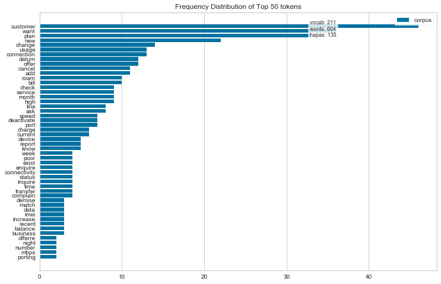

```python
vectorizer = CountVectorizer()
docs       = vectorizer.fit_transform(df[commentTextColumn])
features   = vectorizer.get_feature_names()
plt.figure(figsize=(12,8))
visualizer = FreqDistVisualizer(features=features)
visualizer.fit(docs)
for label in visualizer.ax.texts:
    label.set_size(20)
visualizer.poof()
```

## Word Distribution Analysis for each Topic

This is very important step in analyzing which set of words contribute to each topics. This gives us an idea about how different models would perform and helps us improve the previous steps.

```python
def wordFrequency(reasonCode):
    return (df[df[agentAssignedColumn]==str(reasonCode)][commentTextColumn].str.split(expand=True).stack().value_counts())


def wordFrequencyListPlot(reasonCode, plot = False):
    wordFreqDict = df[df[agentAssignedColumn]==str(reasonCode)][commentTextColumn].str.split(expand=True).stack().value_counts().to_dict()
    wordFreqDictMostCommon = dict(collections.Counter(wordFreqDict).most_common(10)) #Considering only Top 10 words
    print(list(wordFreqDictMostCommon.keys()))
    if plot == True:
        plt.title(str(reasonCode), fontdict=None, loc='center')
        plt.bar(wordFreqDictMostCommon.keys(), wordFreqDictMostCommon.values(), width = 0.1  , color='b');
        plt.figure(figsize=(10,10))
        plt.show();
    return list(wordFreqDictMostCommon.keys())
```

```
Change Plans
['plan', 'change', 'offer', 'customer', 'new', 'want', 'current', 'enquire', 'understand', 'vineeth']
```

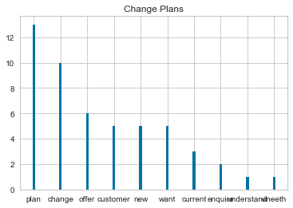

```
Add New Line
['new', 'add', 'line', 'want', 'customer', 'connection', 'know', 'inquire', 'business', 'shaji']
```

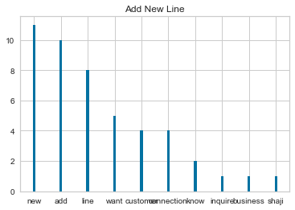

```
Roaming Plans
['roam', 'charge', 'customer', 'plan', 'want', 'month', 'travel', 'inquire', 'check', 'advice']
```

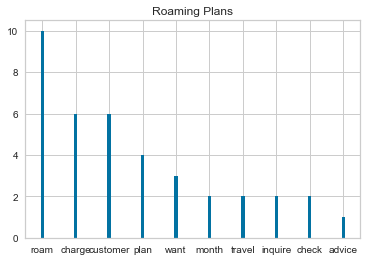

```
Others
['want', 'demise', 'customer', 'imei', 'check', 'report', 'sim', 'device', 'particular', 'block']
```

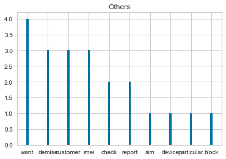

```
High Bill
['bill', 'high', 'want', 'month', 'plan', 'customer', 'complain', 'monthly', 'recent', 'afford']
```

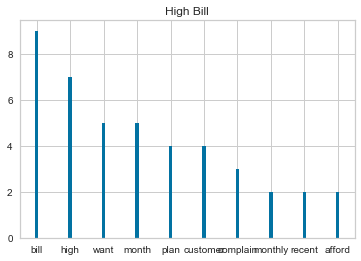

```
Cancel Service
['cancel', 'service', 'customer', 'want', 'new', 'exist', 'start', 'effect', 'john', 'period']
```

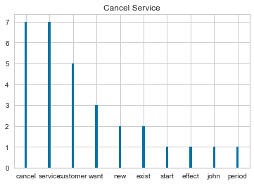

```
Data Usage
['usage', 'datum', 'customer', 'data', 'statistic', 'check', 'balance', 'increase', 'business', 'match']
```

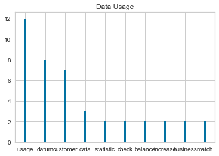

```
Deactivate
['plan', 'deactivate', 'customer', 'offer', 'want', 'special', 'current', 'change', 'unavailability', 'currently']
```

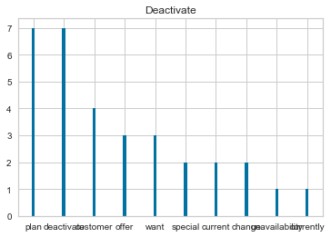

```
Poor Connectivity
['speed', 'connection', 'poor', 'connectivity', 'customer', 'area', 'want', 'face', 'device', 'check']
```

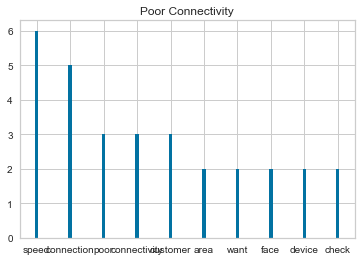

```
Port Out
['port', 'customer', 'want', 'transfer', 'cancel', 'plan', 'idea', 'service', 'ask', 'retain']
```

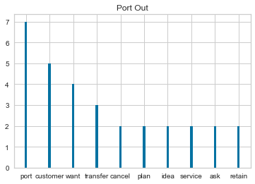

```python
for reasoncode in uniqueTopics:
    print(reasoncode)
    wordFrequencyListPlot(reasoncode, plot = True)
```

Generating WordCloud for each reason to have a visual representation of texts corresponding to each topic. We can also have an overall wordcloud.

```python
def wordCloudGenerator(df, reasonCode, save = False):
    dfReasonCodeSubset = df[df[agentAssignedColumn]==reasonCode]
    wordcloud = WordCloud(max_words=50,background_color='white',max_font_size = 50,width=100, height=100).generate(' '.join(dfReasonCodeSubset[commentTextColumn]))
    plt.imshow(wordcloud)
    plt.title(str(reasonCode), fontdict=None, loc='center')
    plt.figure(figsize=(50,50))
    plt.axis("off")
    plt.show();
    if save:
        plt.savefig('wordCloud'+str(reasonCode)+'.png', bbox_inches='tight')
```